# Taylor Swift Song Analysis: What Makes An Album Good Or Bad, Based On The Features Of Their Songs?

Arvind Ramakrishnan (A0253523L), Jason Matthew Suhari (A0286652U), Jason Ray, Tay Jia Jun Jeremy

2024-11-15

## Introduction

### Background

This project analyzes Taylor Swift’s albums that were released up until 2023, with the latest being *1989 (Taylor’s Version)*.

The [dataset](https://github.com/rfordatascience/tidytuesday/blob/master/data/2023/2023-10-17/readme.md) is sourced from [TidyTuesday](https://github.com/rfordatascience/tidytuesday), featuring the following key variables:

1. **`album_name`**: Name of the album that a specific song belongs to
2. **`danceability`**: A metric of how suitable a song is for dancing (0 - 1)
3. **`energy`**: A metric of how intense and energetic a song is (0 - 1)
4. **`loudness`**: Measure of loudness in decibels (dB)
5. **`speechiness`**: A metric of how many words are spoken in a song (0 - 1)
6. **`acousticness`**: A metric of whether or not a song is acoustic, meaning void of electric amplification (0 - 1)
7. **`valence`**: A metric of how musically positive (i.e., happy, cheerful) a song is (0 - 1)
8. **`tempo`**: The overall estimated tempo of the track, measured in BPM
9. **`album_release`**: The release date of the album, meaning some songs will have the same value for this column
10. **`metacritic_score`**: A score out of 100 that represents the average critical rating for the entire album, meaning some songs will have the same value for this column
11. **`user_score`**: A score out of 100 that represents the average user rating for the entire album, meaning some songs will have the same value for this column

### Main Question

**What are the key differences, in terms of musical features, between the songs of a highly rated album and relatively lower rated album of Taylor Swift?**

### Sub-Questions

1.) How does the metacritic score and user score differ for each Taylor Swift album and what are the good and bad albums?

## Data Parsing and Initialization

### Library Imports

```r
library(ggplot2)
library(dplyr)
library(taylor)
library(tidyverse)
library(viridis)
library(lubridate)
```

### Data Ingestion & Cleaning

The main Taylor Swift datasets that we will be using in our data analysis are the `taylor_albums` and `taylor_album_songs` datasets. We will be omitting the `taylor_all_songs` dataset from the scope of our project since the key variables that we intend to use for our visualizations and analysis are contained in the `taylor_album_songs` and these variables are also repeated in the `taylor_all_songs` dataset and therefore is redundant to the primary objective of our data analysis. **Section 1** which entails **Visualization 1** will only utilize the `taylor_albums` dataset, whereas the `taylor_album_songs` left joined with the `taylor_albums` dataset will be used for anaylsis in **Section 2** and **Section 3** and their visualizations respectively.

The first part is the transformation and cleaning of `taylor_albums` dataset which will be used in **Section 1** and as a part of the data transformation and cleaning we first remove the rows with missing values. Then we remove the albums “Fearless” and “Red” from this data and the analysis in **Section 1** due to the fact that these albums are not present in the `taylor_album_songs` dataset, which will be used in for visualizations and analysis in subsequent sections. Subsequently, we will scale the user scores to be weighted out of 100 by multiplying the `user_score` variable by 10 (as it is originally weighted on a scale of 1-10) Finally, we will use the `pivot_longer` function to tidy the `df_plot1` dataframe into a longer format, since in the original `taylor_albums` dataset, the column headers of the variables `metacritic_score` and `user_score` are actually values that we would like to use in this bar plot visualization to distinctly illustrate the metacritic and user scores separately. We create the new variables `score_type` and `score` to store the type (metacritic or user) of score and the value of the score (weighted out of 100) respectively

```r
# create a dataframe df_plot1 to use for the visualization and analysis in this section
df_plot1 <- drop_na(taylor_albums)
# remove the albums "Fearless" and "Red"
df_plot1 <- df_plot1 %>% filter(!((album_name == "Fearless")|(album_name == "Red")))
# scale the user scores to be weighted out of 100
df_plot1$user_score <- df_plot1$user_score * 10
# tidy the data
df_plot1 <- df_plot1 %>% pivot_longer(`metacritic_score`:`user_score`, names_to = "score_type", values_to = "score")
df_plot1
```

```
## # A tibble: 22 × 5
##    album_name   ep    album_release score_type       score
##    <chr>        <lgl> <date>        <chr>            <dbl>
##  1 Taylor Swift FALSE 2006-10-24    metacritic_score    67
##  2 Taylor Swift FALSE 2006-10-24    user_score          84
##  3 Speak Now    FALSE 2010-10-25    metacritic_score    77
##  4 Speak Now    FALSE 2010-10-25    user_score          86
##  5 1989         FALSE 2014-10-27    metacritic_score    76
##  6 1989         FALSE 2014-10-27    user_score          83
##  7 reputation   FALSE 2017-11-10    metacritic_score    71
##  8 reputation   FALSE 2017-11-10    user_score          83
##  9 Lover        FALSE 2019-08-23    metacritic_score    79
## 10 Lover        FALSE 2019-08-23    user_score          84
## # ℹ 12 more rows
```

In this part, we first transform and clean the `taylor_album_songs` dataset by first selecting and keeping only the `album_name`, `danceability`, `energy`, `loudness`, `speechiness`, `acousticness`, `valence` and `tempo` variables and drop the rest as there are the variables of interest that will be used for the analysis in **Section 2** and **Section 3**. Secondly, we remove all the rows with missing values and finally we join the two datasets together using a left join so that each song in the `taylor_album_songs` dataset can be associated/linked to its respective album names from `taylor_albums`, which faciliates a meaningful analysis. We store this transformed and cleaned version of the `taylor_album_songs` dataset joined with the `taylor_albums` dataset in a dataframe object called `df` which is the main data object that will be used in **Section 2** and **Section 3**.

```r
data <- tidytuesdayR::tt_load('2023-10-17')
cols_to_select <- c("album_name", "danceability", "energy", "loudness", "speechiness", "acousticness", "valence", "tempo")

taylor_albums <- data$taylor_albums

df <- data$taylor_album_songs %>%
  select(all_of(cols_to_select)) %>%
  drop_na() %>%
  left_join(taylor_albums, by = "album_name") %>%
  select(-c("ep"))
```

### Exploratory Data Analysis

This portion comprises the exploratory data analysis that computes key summary statistics to ascertain the key characteristics and features of the dataset stored in `df`.

```r
glimpse(df)

# looking at distribution of all data
dist <- df %>%
  select(where(is.numeric)) %>%
  pivot_longer(cols = everything(), names_to = "var", values_to = "val") %>%
  ggplot(aes(x = val)) +
  geom_histogram(bins = 30) +
  labs(title = "Distribution of All Numeric Variables") +
  theme_bw() +
  facet_wrap(~var, scales = "free") +
  theme(
    plot.title = element_text(hjust = 0.5),
    axis.title.x = element_blank(),
    axis.title.y = element_blank()
    )

# finding outliers
outliers <- df %>%
  select(where(is.numeric)) %>%
  pivot_longer(cols = everything(), names_to = "var", values_to = "val") %>%
  ggplot(aes(x = var, y = val)) +
  geom_boxplot() +
  labs(title = "Boxplot for Potential Outliers in Taylor Swift's Songs") +
  theme_bw() +
  facet_wrap(~var, scales = "free") +
  theme(
    plot.title = element_text(hjust = 0.5),
    axis.title.x = element_blank(),
    axis.title.y = element_blank()
    )

heatmap <- df %>%
  select(where(is.numeric)) %>%
  cor() %>%
  as.data.frame() %>%
  rownames_to_column(var = "x") %>%
  pivot_longer(cols = -x, names_to = "y", values_to = "value") %>%
  ggplot(aes(x = x, y = y, fill = value)) +
  geom_tile(color = "black") +
  labs(title = "Correlation Heatmap of Numerical Variables", x = "", y = "")
  theme_minimal() +
  theme(
    axis.text.x = element_text(angle = 90, vjust = 1, hjust = 1),
    plot.title = element_text(hjust = 0.5)
  )
```

[output not shown]

## Section 1

### Visualization 1

*Bar chart that plots the values of metacritic score and user score of each taylor swift album*

**Part 1: Bar Plot** Using the fully transformed and cleaned version of the `taylor_albums` dataset which is now stored in the dataframe `df_plot1`, we now plot the bar chart using the `geom_col` function. For this visualization we use the variables `album_names`, `score` and `score_type`. The rationale behind choosing a bar plot for this visualization is that it allows our readers to not only view the metacritic and user scores of each albums more vividly, but it also enables them to compare these scores side by side in an easier and comprehensible manner due to the presence of distinct bars for both the metacritic and user score of each album respectively.This will facilitate the readers to ascertain which albums will be used in the subsequent sections.

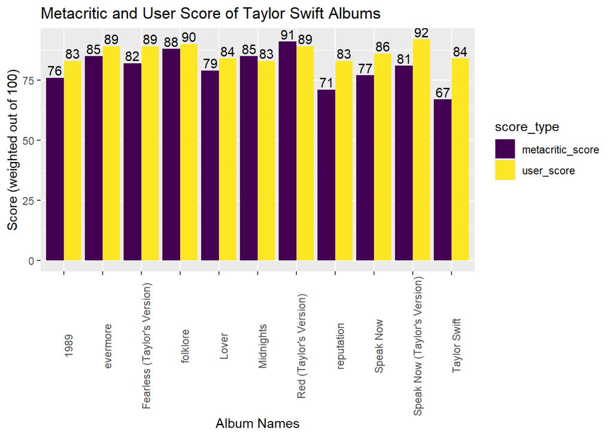

```r
ggplot(df_plot1, aes(album_name, y = score, fill = score_type)) +
  geom_col(position = "dodge") +
  labs(title = "Metacritic and User Score of Taylor Swift Albums",
       x = "Album Names",
       y = "Score (weighted out of 100)" ) +
  scale_fill_viridis(option = "viridis", discrete = TRUE) +
  theme(axis.text.x = element_text(angle = 90)) +
  geom_text(aes(x = album_name, y = score, label = score),
            position = position_dodge(width = 0.9),
            vjust = -0.25)
```